# R Notebook

This Notebook performs the analysis of the First part of NUTRISHIEDL STUDY I. Meaning it imports, and analyses all the data from the OBSERVATIONAL part of the study.

```r
#Load Packages
library(ggplot2)
library(readxl)
library(dplyr)
library(reshape2)
library(ggpubr)
library(vtable)
library(network)
library(sna)
library(igraph)
library(ggraph)
library(tidygraph)
library(qgraph)
library(ggraph)
library(mixOmics)
library(grid)
```

First we load all data-sets, and prepare them for analysis

```r
#Microbiome data
MicrobiomeData<- read.csv("Statistics/Study1-Data/MicrobiomeData.csv")
MicrobiomeVariables<-colnames(MicrobiomeData)[2:length(colnames(MicrobiomeData))]
#Kidmed scores
KidmedScores <- read.csv("Statistics/Study1-Data/KidmedScores.csv")

#And the conditions
Conditions<-read.csv("Statistics/Study1-Data/Conditions.csv"
)

KidmedScores<-merge(KidmedScores,Conditions,by.x = "Id",by.y = "Id",all = TRUE)
#Merging kidmed and metabolome
MicroKidmed<-merge(KidmedScores,MicrobiomeData,by.x = "Id",by.y = "Id",all = TRUE)

#Metabolome
BileAcids <- read_excel("Statistics/Study1-Data/Metabolome.xlsx",sheet = "BA")
SCFA<-read_excel("Statistics/Study1-Data/Metabolome.xlsx",sheet = "SCFA")

Metabolome<-merge(BileAcids,SCFA,by.x = "Id",by.y = "Id",all = TRUE)
MetabolomeVariables<-colnames(Metabolome)[2:length(colnames(Metabolome))]
ScfaVariables<-colnames(SCFA)[2:length(colnames(SCFA))]
#And now for Food groups
FoodGroups <- read.csv("Statistics/Study1-Data/FoodGroups.csv",
                       stringsAsFactors = FALSE)
FoodGroupsVariables<-colnames(FoodGroups)[2:length(colnames(FoodGroups))]

#We will now merge microbiome and Kidmd with FoodGroup
FoodMicrobiome<-merge(MicroKidmed,FoodGroups, by.x = "Id",by.y = "Id",all = TRUE)

#And create a complete dataset with all variables
AllVariables<-merge(FoodMicrobiome,Metabolome,by.x = "Id",by.y = "Id",all = TRUE)

#We now load the dataset with the Height, weight and BMI
BmiData <- read_xlsx("Statistics/Study1-Data/BMI.xlsx",sheet = "BMI")
AllVariables<-merge(AllVariables,BmiData,by.x = "Id",by.y = "Id",all = TRUE)

#we now keep only the IDs which were in the Observation study
AllVariables<-AllVariables[which(AllVariables$Id %in% Conditions$Id),]

#We now create a few variables we need
AllVariables$TotalEnergyIntake=
  4*AllVariables$MacroNutrientsCalculation.TotalProteinIntakeG+
  4*AllVariables$MacroNutrientsCalculation.TotalCarbohydrateIntakeG+
  9*AllVariables$MacroNutrientsCalculation.TotalFatIntakeG+
  7*AllVariables$MacroNutrientsCalculation.TotalAlcoholIntakeG
FoodGroupsVariables<-c(FoodGroupsVariables,"TotalEnergyIntake")

NumericalVariables<-colnames(AllVariables)[
  !(colnames(AllVariables)%in%c("Id","Condition","Adherence"))
]
NumericalVariablesData<-AllVariables[NumericalVariables]

VariableTypes<-data.frame(Name=NumericalVariables,Type="None")
VariableTypes$Type[which(VariableTypes$Name %in% colnames(MicrobiomeData))]<-"Microbiome"
VariableTypes$Type[which(VariableTypes$Name %in% colnames(KidmedScores))]<-"Kidmed"
VariableTypes$Type[which(VariableTypes$Name %in% colnames(BileAcids))]<-"BileAcids"
VariableTypes$Type[which(VariableTypes$Name %in% colnames(SCFA))]<-"SCFA"
#VariableTypes$Type[which(VariableTypes$Name %in% colnames(Metabolome))]<-"Metabolome"
VariableTypes$Type[which(VariableTypes$Name %in% colnames(FoodGroups))]<-"FoodGroups"
VariableTypes$Type[which(VariableTypes$Name %in% c("TotalEnergyIntake"))]<-"FoodGroups"

SelectedVariables<-c("Kidmed",MicrobiomeVariables,ScfaVariables,"BMI")

#Last, we parepare a csv with all necessary variables, for sharing where needed
write.csv(x = AllVariables[SelectedVariables,],file = "SupplementaryData1.csv",sep = ","
)
```

The following sets of blocks will perform “unidimensional analysis of the data”

In the following block, we prepare the “correltion Matrix” which can be used to plot heatmaps

```r
CorrMat<-#na.omit(
  round(cor(AllVariables[,SelectedVariables],
            use="pairwise.complete.obs",method = "spearman"),2)
#)
CorrMat[which(is.na(CorrMat))]<-0
# reorder corr matrix
# using corr coefficient as distance metric
dist <- as.dist((1-CorrMat)/2)
# hierarchical clustering the dist matrix
hc <- hclust(dist,method = "median")
CorrMat <-CorrMat[hc$order, hc$order]

# reduce the size of correlation matrix
melted_cormat <- melt(CorrMat)
melted_cormat$Var1<-as.character(melted_cormat$Var1)
melted_cormat$Var2<-as.character(melted_cormat$Var2)

#We now add a "significance" test to the correlation matrix:

for(i in 1:dim(melted_cormat)[1]){
  Pval<-cor.test(AllVariables[,melted_cormat$Var1[i]],
                 AllVariables[,melted_cormat$Var2[i]],method="spearman")$p.value
  if(!is.numeric(Pval) || is.na(Pval) || Pval > 0.05){
    Significance<-NA
  }else if(Pval > 0.01){
    Significance<-1
  }else if(Pval > 0.001){
    Significance<-2
  }else if(Pval <= 0.001){
    Significance<-3
  }else{
    Significance<-NA
  }

  melted_cormat$Pvalue[i]<-Pval
  melted_cormat$Significance[i]<-Significance
}
melted_cormat$Significance<-as.numeric(melted_cormat$Significance)
```

We now create Boxplots for All variables in relationship to the conditions. These are Figures 2, 3 and 4.

```r
#my_comparisons <- list( c("HC", "Obese"), c("HC", "T1D"), c("T1D", "Obese") )
#Micro<-colnames(MicrobiomeData)[9]
#my_comparisons<-list( c("HC", "Obese"), c("Obese", "T1D"), c("HC", "T1D") )
#for (Variable in colnames(AllVariables)[!(colnames(AllVariables)%in%c("Id","Condition","Adherence"))]){
Plots<-list()
for (Variable in SelectedVariables){
  plot<-ggplot(data = AllVariables,aes(x=Condition,y=get(Variable)))+
    geom_boxplot(notch = TRUE,aes(fill=Condition))+
    theme_bw()+
    #stat_compare_means(comparisons = my_comparisons, method = "kruskal.test")
    stat_pwc(label = "p.format", method = "wilcox.test",
             hide.ns = TRUE,p.adjust.method = "none",size = 1.5,label.size = 7)+
    theme(
      legend.position = "none",
      text=element_text(size=20),
      axis.title.x = element_blank(),
      axis.text = element_text(size=20),
    )+
    scale_fill_manual(values = c("steelblue","tomato","plum"))
  if(Variable %in% MetabolomeVariables){
    plot<-plot+ylab(paste(Variable,"[µmol/g creatinine]"))
  }else if(Variable %in% MicrobiomeVariables){
    plot<-plot+ylab(paste(Variable,"[relative abundance]"))
  }else{
    plot<-plot+ylab(Variable)
  }

  #We now save the plots in the different folders according to data type.

  #The microbiome BoxPlots are the ones shown in Figure 3
  if(Variable %in% MicrobiomeVariables){
    ggsave(filename = paste("Statistics/Plots/BoxPlotsConditionsMicrobiome/",Variable,".pdf",sep = ""),
           plot = plot)


  }else if(Variable %in% ScfaVariables){
    #Next, we store the Scfa data which is shown in Figure 4
    ggsave(filename = paste("Statistics/Plots/BoxPlotsConditionsScfa/",Variable,".pdf",sep = ""),
           plot = plot)


  }else{
    #The remaining variables include the KIDMED, which is shown in Figure 2
    ggsave(filename = paste("Statistics/Plots/BoxPlotsConditionsSelect/",Variable,".pdf",sep = ""),
           plot = plot)
  }
}
```

We can now make series of “heatmaps” where we plot several variables and color code the different correlations. This is Figure 8

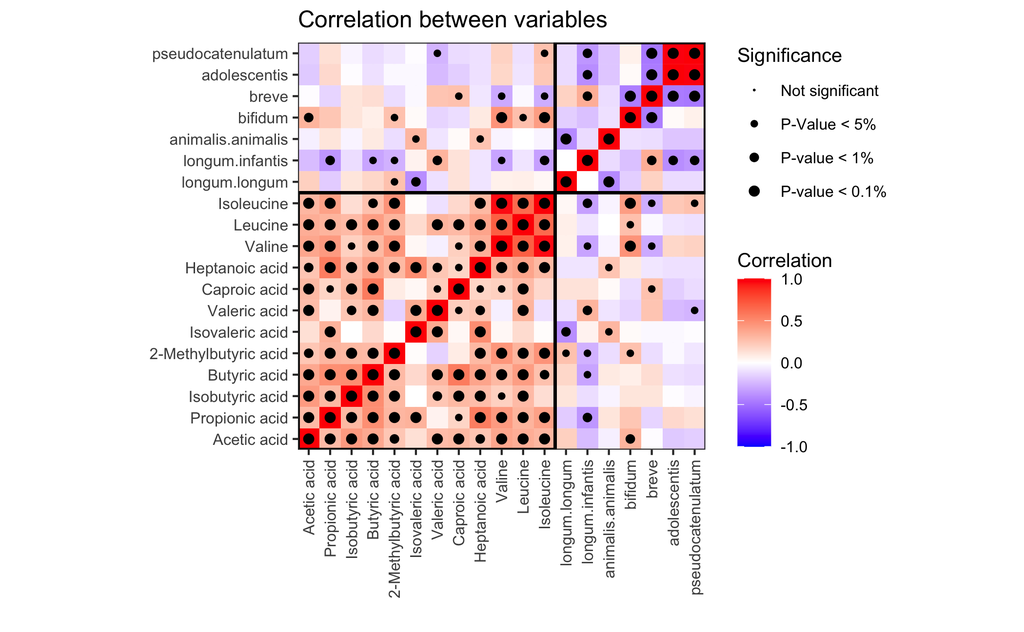

```r
#Plot of all variables
MicrobiomeVariablesPlot<-MicrobiomeVariables[which(MicrobiomeVariables != "animalis.lactis")]
TilePlot<-ggplot(data = melted_cormat, aes(x=Var1, y=Var2, fill=value))+
  geom_tile()+
  theme_bw() + #xlab("Varible 1") + ylab("Variable 2")+
  xlab("") + ylab("")+
  coord_equal(ratio = 1)+
  scale_x_discrete(expand = c(0,0),limits = c(ScfaVariables,MicrobiomeVariablesPlot))+
  scale_y_discrete(expand = c(0,0),limits = c(ScfaVariables,MicrobiomeVariablesPlot)) +
  scale_fill_gradient2(low = "blue", mid="white", high = "red",
                       limits=c(-1,1),name="Correlation")+
  theme(axis.text.x = element_text(angle = 90, vjust = 0.5, hjust=1),
        text = element_text(size = 10))+
  ggtitle("Correlation between variables")+
  geom_point(aes(size=Significance),fill="black")+
  scale_size_continuous(limits = c(0,3),
                        range=c(0,2),
                        name="Significance",
                        labels=c("Not significant","P-Value < 5%","P-value < 1%",
                                 "P-value < 0.1%"))+
  # geom_rect(aes(xmin="Acetic.acid",ymin="Acetic.acid",xmax="Isoleucine",ymax="Isoleucine"),color="black",size=1)
  geom_rect(aes(xmin=0.5,ymin=0.5,xmax=12.5,ymax=12.5),color="black",size=0.7,fill=NA)+
  geom_rect(aes(xmin=12.5,ymin=12.5,xmax=19.5,ymax=19.5),color="black",size=0.7,fill=NA)
# ggsave(filename = "Statistics/TilePlot.pdf",plot = TilePlot,units = "px",width = 5000,height = 5000
# )
TilePlot
```

We will now follow with Partial Least Square Discriminant analysis (PLS-DA), to find the predictors for the different conditions. The first one (Microbiome), correspods to Figure 5

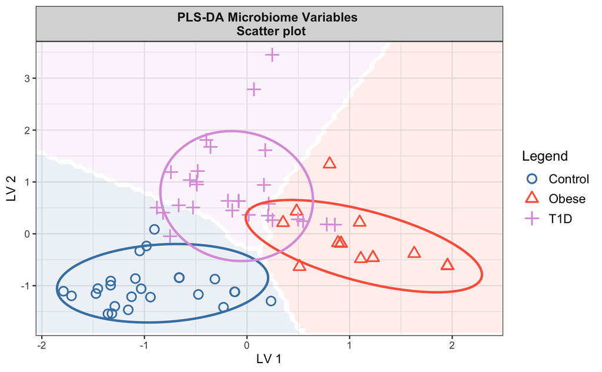

```r
#Begin by selecting the independent and the response variables
SelectedColors<-c("steelblue","tomato","plum")
FittedVariables<-AllVariables[,MicrobiomeVariables]
Response<-AllVariables[,"Condition"]
ModelPLS<-splsda(FittedVariables,Response,scale = TRUE,ncomp = 2)
background.mahal <-  background.predict(ModelPLS,
                                        comp.predicted = 2,
                                        dist = 'mahalanobis.dist')
plotIndiv(ModelPLS,
          rep.space = 'XY-variate',
          ellipse = TRUE,  # plot using the ellipses
          legend = TRUE,
          background = background.mahal,
          ind.names=FALSE,
          title = "PLS-DA Microbiome Variables \n Scatter plot",
          size.title = rel(1),
          X.label = "LV 1",
          Y.label = "LV 2",
          style = "ggplot2",
          col.per.group = SelectedColors
)
```